# Question Answering

## Overview

Recall the overall workflow for retrieval augmented generation (RAG):

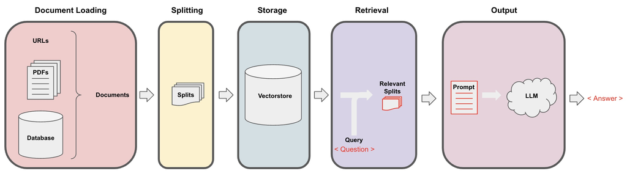

We discussed `Document Loading` and `Splitting` as well as `Storage` and `Retrieval`.

Let's load our vectorDB.

```python
import os
import openai
import sys
sys.path.append('../..')

from dotenv import load_dotenv, find_dotenv
_ = load_dotenv(find_dotenv()) # read local .env file

openai.api_key  = os.environ['OPENAI_API_KEY']
```

The code below was added to assign the openai LLM version filmed until it is deprecated, currently in Sept 2023. LLM responses can often vary, but the responses may be significantly different when using a different model version.

```python
import datetime
current_date = datetime.datetime.now().date()
if current_date < datetime.date(2023, 9, 2):
    llm_name = "gpt-3.5-turbo-0301"
else:
    llm_name = "gpt-3.5-turbo"
print(llm_name)
```

```
gpt-3.5-turbo
```

### This snippet initializes an embedding function & Vector DB from persist directory

```python
from langchain.vectorstores import Chroma
from langchain.embeddings.openai import OpenAIEmbeddings
persist_directory = 'docs/chroma/'
embedding = OpenAIEmbeddings()
vectordb = Chroma(persist_directory=persist_directory,
                  embedding_function=embedding)
```

```python
# Inspecting location content -->
# We see some parquet files and metadata that is likely \
#    bound and read by the database to initialize
!ls -lhat docs/chroma/
```

```
total 2.6M
drwxr-xr-x. 1 jovyan jovyan   73 Jun  4 00:41 .
-rw-r--r--. 1 jovyan jovyan  559 Jun  4 00:41 chroma-collections.parquet
-rw-r--r--. 1 jovyan jovyan 2.6M Jun  4 00:41 chroma-embeddings.parquet
drwxr-xr-x. 1 jovyan jovyan   20 May 16 02:45 ..
drwxr-xr-x. 1 jovyan jovyan  16K May 16 02:45 index
```

```python
print(vectordb._collection.count())
```

```
209
```

```python
# To understand what embedding model is being used
print(embedding.model)
```

```
text-embedding-ada-002
```

```python
question = "What are major topics for this class?"
docs = vectordb.similarity_search_with_relevance_scores(question,k=3)
len(docs)
```

```
3
```

```python
docs
```

```
[(Document(page_content="statistics for a while or maybe algebra, we'll go over those in the discussion sections as a \nrefresher for those of you that want one.  \nLater in this quarter, we'll also use the disc ussion sections to go over extensions for the \nmaterial that I'm teaching in the main l…
  0.39060893654823303),
 (Document(page_content="statistics for a while or maybe algebra, we'll go over those in the discussion sections as a \nrefresher for those of you that want one.  \nLater in this quarter, we'll also use the disc ussion sections to go over extensions for the \nmaterial that I'm teaching in the main l…
  0.3906983733177185),
 (Document(page_content="middle of class, but because there won't be video you can safely sit there and make faces \nat me, and that won't show, okay?  \nLet's see. I also handed out this — ther e were two handouts I hope most of you have, \ncourse information handout. So let me just sa y a few word…
  0.3969250023365021)]
```

```python
# Large language model initialized based on the datetime as described in cell above
from langchain.chat_models import ChatOpenAI
llm = ChatOpenAI(model_name=llm_name, temperature=0)
```

### RetrievalQA chain

```python
from langchain.chains import RetrievalQA
```

```python
qa_chain = RetrievalQA.from_chain_type(
    llm,
    retriever=vectordb.as_retriever()
)
```

```python
result = qa_chain({"query": question})
```

```python
print("Result data type is - {type_result},\nResult full data is - {full_data}".\
      format(type_result=type(result),
             full_data=result))
```

```
Result data type is - <class 'dict'>,
Result full data is - {'query': 'What are major topics for this class?', 'result': 'The major topics for this class include machine learning, statistics, and algebra. Additionally, there will be discussions on extensions of the material covered in the main lectures.'}
```

### Prompt

```python
from langchain.prompts import PromptTemplate

# Build prompt
template = """Use the following pieces of context to answer the question at the end. If you don't know the answer, just say that you don't know, don't try to make up an answer. Use three sentences maximum. Keep the answer as concise as possible. Always say "thanks for asking!" at the end of the answer.
{context}
Question: {question}
Helpful Answer:"""
QA_CHAIN_PROMPT = PromptTemplate.from_template(template)
```

```python
# Inspect the prompt used in the chain
print(QA_CHAIN_PROMPT, "\n\n#####\n\n", type(QA_CHAIN_PROMPT))
```

```
input_variables=['context', 'question'] output_parser=None partial_variables={} template='Use the following pieces of context to answer the question at the end. If you don\'t know the answer, just say that you don\'t know, don\'t try to make up an answer. Use three sentences maximum. Keep the answer…

#####

 <class 'langchain.prompts.prompt.PromptTemplate'>
```

```python
# Run chain
qa_chain = RetrievalQA.from_chain_type(
    llm,
    retriever=vectordb.as_retriever(),
    return_source_documents=True,
    chain_type_kwargs={"prompt": QA_CHAIN_PROMPT}
)
```

```python
# Inspecting the qa_chain object
print("qa_chain type - {0}\navailable methods - {1}".format(type(qa_chain), dir(qa_chain)))
```

[output not shown]

```python
question = "Is probability a class topic?"
```

```python
result = qa_chain({"query": question})
```

```python
result["result"]
```

```
'Yes, probability is a topic covered in the class, as familiarity with basic probability and statistics is assumed. Thanks for asking!'
```

```python
result["source_documents"][0]
```

```
Document(page_content="of this class will not be very program ming intensive, although we will do some \nprogramming, mostly in either MATLAB or Octa ve. I'll say a bit more about that later.  \nI also assume familiarity with basic proba bility and statistics. So most undergraduate \nstatistics clas…
```

### RetrievalQA chain types

```python
qa_chain_mr = RetrievalQA.from_chain_type(
    llm,
    retriever=vectordb.as_retriever(),
    chain_type="map_reduce"
)
```

```python
result = qa_chain_mr({"query": question})
```

```python
result["result"]
```

```
'Yes, probability is a class topic in the document. The instructor assumes familiarity with basic probability and statistics, including concepts like random variables, expectation, variance, and more. The course may involve some programming in MATLAB or Octave, but it is not very programming-intensi…
```

If you wish to experiment on the `LangSmith platform` (previously known as LangChain Plus):

- Go to [LangSmith](https://www.langchain.com/langsmith) and sign up
- Create an API key from your account's settings
- Use this API key in the code below
- uncomment the code  
  Note, the endpoint in the video differs from the one below. Use the one below.

```python
import os
os.environ["LANGCHAIN_TRACING_V2"] = "true"
os.environ["LANGCHAIN_ENDPOINT"] = "https://api.langchain.plus"
os.environ["LANGCHAIN_API_KEY"] = "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" # replace dots with your api key
```

```python
qa_chain_mr = RetrievalQA.from_chain_type(
    llm,
    retriever=vectordb.as_retriever(),
    chain_type="map_reduce"
)
result = qa_chain_mr({"query": question})
result["result"]
```

```
'Yes, probability is a class topic in the document.'
```

```python
qa_chain_mr = RetrievalQA.from_chain_type(
    llm,
    retriever=vectordb.as_retriever(),
    chain_type="refine"
)
result = qa_chain_mr({"query": question})
result["result"]
```

```
'The original answer already provides a comprehensive explanation of how probability is a class topic in the course, including its importance in understanding classification algorithms. The additional context about using discussion sections to review statistics and algebra as refreshers and to cover…
```

### RetrievalQA limitations

QA fails to preserve conversational history.

```python
qa_chain = RetrievalQA.from_chain_type(
    llm,
    retriever=vectordb.as_retriever()
)
```

```python
question = "Is probability a class topic?"
result = qa_chain({"query": question})
result["result"]
```

```
'Yes, probability is a class topic in the course being described. The instructor assumes familiarity with basic probability and statistics.'
```

### This question is posed as "StuffDocuments" chain

Here, all the context was shared with an LLM in a single session, this strategy is not very scalable as LLM context windows are limited which limits the amount of information they can handle for 1 query.

In the image below, note how all in the StuffDocuments call the context and metadata is all passed to the LLM with the final question, LLM returns the answer in a single pass

[figure not shown]

```python
question = "why are those prerequesites needed?"
result = qa_chain({"query": question})
result["result"]
```

```
'The prerequisites for the class are needed because the course assumes that all students have a basic knowledge of computer science and computer skills. This foundational knowledge is essential for understanding the concepts and techniques taught in the class, such as big-O notation and basic comput…
```

### The above question was posed as a "StuffDocuments chain"

Here, all the context was shared with an LLM in a single session, this strategy is not very scalable as LLM context windows are limited which limits the amount of information they can handle for 1 query.

In the image below, note how all the context is bunched together in one call, we get our answer from a single call which leads to good response time but limits amount of context that can be shared

[figure not shown]

Note, The LLM response varies. Some responses **do** include a reference to probability which might be gleaned from referenced documents. The point is simply that the model does not have access to past questions or answers, this will be covered in the next section.